# Time Series Final Project

2023-11-20

```r
library(zoo)
library(lubridate)
library(mgcv)
library(TSA)
library(dynlm)
library(tseries)
library(vars)
library(rugarch)
library(forecast)
library(wesanderson)
library(knitr)
```

```r
#Read in data, split into full and abridged data
full.data<-read.csv("jena_climate_2009_2016.csv")
full.data$Date.Time <- as.POSIXct(full.data$Date.Time, format="%d.%m.%Y %H:%M:%S")
full.data$Date <- as.Date(full.data$Date.Time)
full.data$Hour <- hour(full.data$Date.Time)
```

```r
df <- data.frame(datetime = full.data$Date.Time, date = full.data$Date, hour = full.data$Date.Time, pressure <- full.data$p..mbar., temperature = full.data$Tpot..K., humidity = full.data$sh..g.kg.)
```

```r
data.daily <- aggregate(df[-c(1,2,3)], list(df$date), mean)
colnames(data.daily) <- c("date", "pressure", "temperature", "humidity")
data.daily$month <- month(data.daily$date)

data.hourly <- aggregate(df[-c(1,2,3)], list(df$date, df$hour), mean)
colnames(data.hourly) <- c("date", "hour", "pressure", "temperature", "humidity")
data.hourly$month <- month(data.hourly$date)

daily.training.data <- data.daily[1:2879,]
daily.training.date <- data.daily[1:2879,1]
daily.testing.data <- data.daily[2880:2921,]
daily.testing.date <- data.daily[2880:2921,1]
daily.training.month <- data.daily[1:2879,5]
daily.testing.month <- data.daily[2880:2921,5]

test.yday <- yday(daily.testing.date[1])

daily.pressure.ts <- ts(data.daily$pressure, frequency = 365, start=c(2009,1))
daily.temperature.ts <- ts(data.daily$temperature, frequency = 365, start=c(2009,1))
daily.humidity.ts <- ts(data.daily$humidity, frequency = 365, start=c(2009,1))

daily.pressure.train.ts <- ts(daily.training.data$pressure, frequency = 365, start=c(2009,1))
daily.temp.train.ts <- ts(daily.training.data$temperature, frequency = 365, start=c(2009,1))
daily.humidity.train.ts <- ts(daily.training.data$humidity, frequency = 365, start=c(2009,1))

daily.pressure.test.ts <- ts(daily.testing.data$pressure, frequency = 365, start=c(2016,test.yday))
daily.temp.test.ts <- ts(daily.testing.data$temperature, frequency = 365, start=c(2016,test.yday))
daily.humidity.test.ts <- ts(daily.testing.data$humidity, frequency = 365, start=c(2016,test.yday))
```

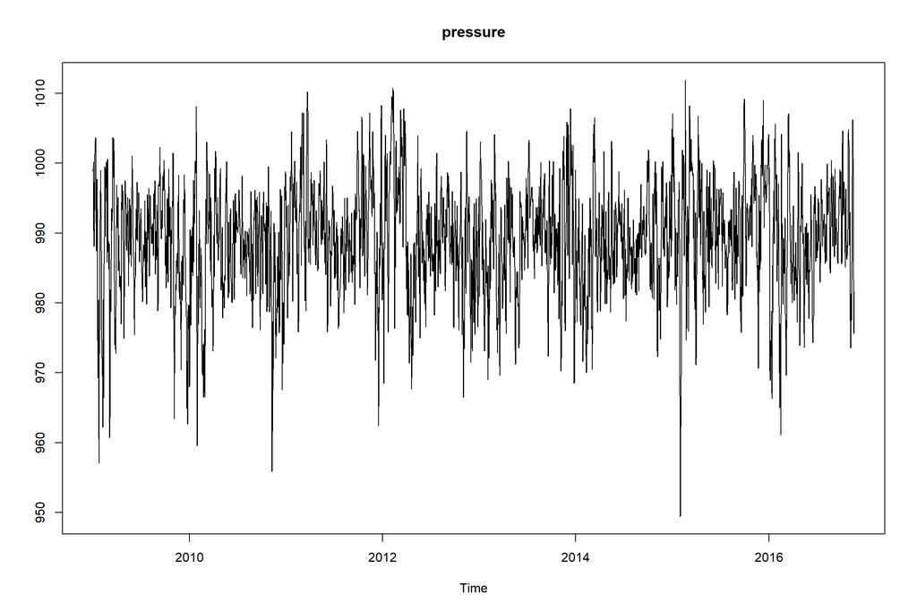

```r
ts.plot(daily.pressure.train.ts, type="l", main=paste("pressure"),ylab="")
```

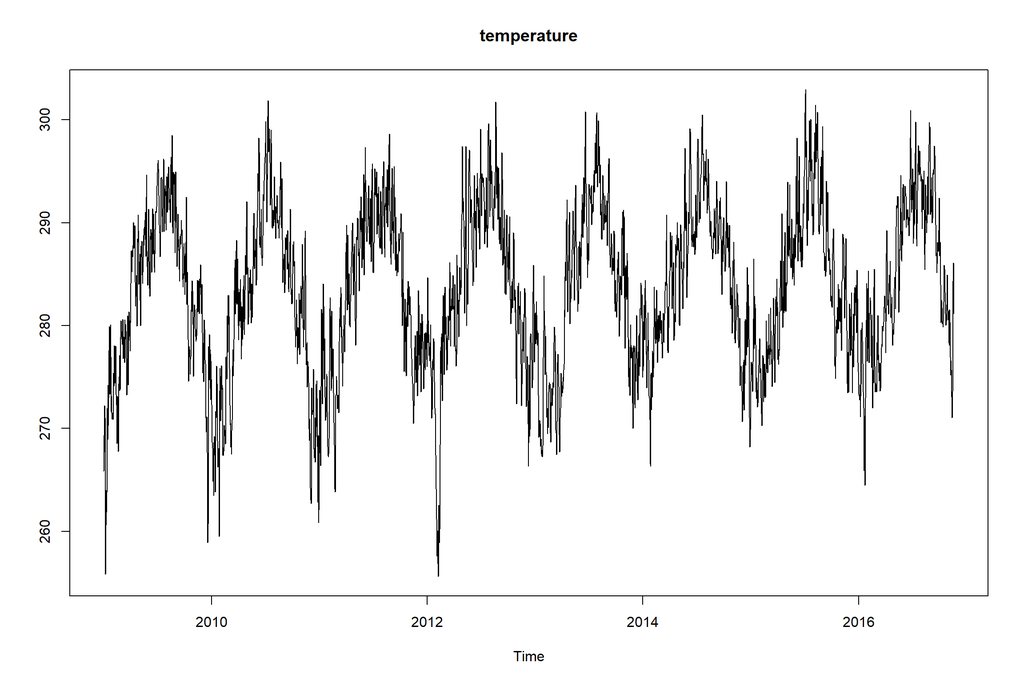

```r
ts.plot(daily.temp.train.ts, type="l", main=paste("temperature"),ylab="")
```

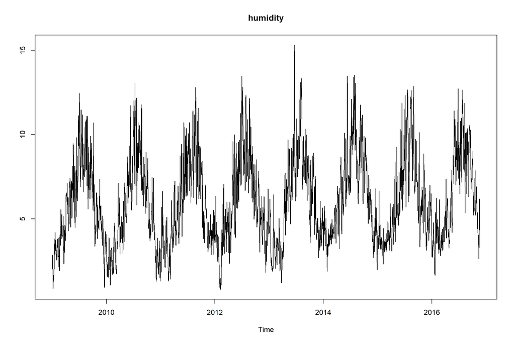

```r
ts.plot(daily.humidity.train.ts, type="l", main=paste("humidity"),ylab="")
```

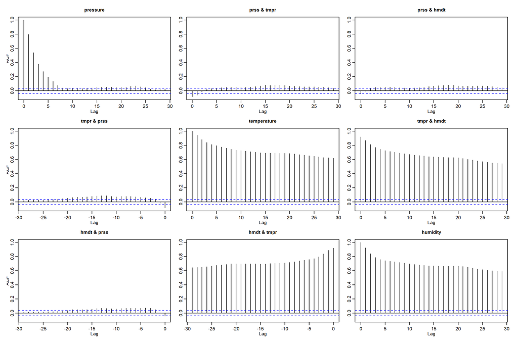

```r
stats::acf(as.matrix(daily.training.data[-c(1,5)]))
```

## Non-parametric trend and ANOVA monthly seasonality

```r
daily.time.pts <- c(1:length(daily.training.date))
daily.time.pts <- c(daily.time.pts - min(daily.time.pts))/max(daily.time.pts)
```

### Pressure

```r
gam1.fitted = gam(daily.pressure.train.ts ~ s(daily.time.pts)+factor(daily.training.month))
summary(gam1.fitted)
```

```
##
## Family: gaussian
## Link function: identity
##
## Formula:
## daily.pressure.train.ts ~ s(daily.time.pts) + factor(daily.training.month)
##
## Parametric coefficients:
##                                 Estimate Std. Error  t value Pr(>|t|)
## (Intercept)                    988.29162    0.50345 1963.024  < 2e-16 ***
## factor(daily.training.month)2   -0.72118    0.72098   -1.000 0.317262
## factor(daily.training.month)3    2.35401    0.70459    3.341 0.000846 ***
## factor(daily.training.month)4    0.07709    0.71134    0.108 0.913712
## factor(daily.training.month)5    0.32222    0.70677    0.456 0.648492
## factor(daily.training.month)6    1.02128    0.71413    1.430 0.152798
## factor(daily.training.month)7    0.53038    0.71017    0.747 0.455225
## factor(daily.training.month)8    1.23343    0.71230    1.732 0.083448 .
## factor(daily.training.month)9    2.52162    0.72038    3.500 0.000472 ***
## factor(daily.training.month)10   2.44909    0.71786    3.412 0.000655 ***
## factor(daily.training.month)11  -1.12845    0.72876   -1.548 0.121624
## factor(daily.training.month)12   0.33730    0.73621    0.458 0.646873
## ---
## Signif. codes:  0 '***' 0.001 '**' 0.01 '*' 0.05 '.' 0.1 ' ' 1
##
## Approximate significance of smooth terms:
##                     edf Ref.df     F p-value
## s(daily.time.pts) 8.653  8.965 8.836  <2e-16 ***
## ---
## Signif. codes:  0 '***' 0.001 '**' 0.01 '*' 0.05 '.' 0.1 ' ' 1
##
## R-sq.(adj) =  0.0419   Deviance explained = 4.85%
## GCV = 61.873  Scale est. = 61.429    n = 2879
```

### Temperature

```r
gam2.fitted = gam(daily.temp.train.ts ~ s(daily.time.pts)+factor(daily.training.month))
summary(gam2.fitted)
```

```
##
## Family: gaussian
## Link function: identity
##
## Formula:
## daily.temp.train.ts ~ s(daily.time.pts) + factor(daily.training.month)
##
## Parametric coefficients:
##                                Estimate Std. Error  t value Pr(>|t|)
## (Intercept)                    274.0294     0.2670 1026.228  < 2e-16 ***
## factor(daily.training.month)2    0.7065     0.3824    1.848   0.0647 .
## factor(daily.training.month)3    4.4256     0.3737   11.843  < 2e-16 ***
## factor(daily.training.month)4    9.8243     0.3773   26.041  < 2e-16 ***
## factor(daily.training.month)5   13.2875     0.3748   35.448  < 2e-16 ***
## factor(daily.training.month)6   16.4009     0.3788   43.302  < 2e-16 ***
## factor(daily.training.month)7   19.3199     0.3767   51.293  < 2e-16 ***
## factor(daily.training.month)8   18.4052     0.3778   48.717  < 2e-16 ***
## factor(daily.training.month)9   14.3539     0.3821   37.566  < 2e-16 ***
## factor(daily.training.month)10   9.0388     0.3808   23.738  < 2e-16 ***
## factor(daily.training.month)11   5.6022     0.3865   14.493  < 2e-16 ***
## factor(daily.training.month)12   1.8139     0.3905    4.645 3.55e-06 ***
## ---
## Signif. codes:  0 '***' 0.001 '**' 0.01 '*' 0.05 '.' 0.1 ' ' 1
##
## Approximate significance of smooth terms:
##                   edf Ref.df     F p-value
## s(daily.time.pts) 8.7  8.974 15.02  <2e-16 ***
## ---
## Signif. codes:  0 '***' 0.001 '**' 0.01 '*' 0.05 '.' 0.1 ' ' 1
##
## R-sq.(adj) =  0.722   Deviance explained = 72.4%
## GCV = 17.403  Scale est. = 17.277    n = 2879
```

### Humidity

```r
gam3.fitted = gam(daily.humidity.train.ts ~ s(daily.time.pts)+factor(daily.training.month))
summary(gam3.fitted)
```

```
##
## Family: gaussian
## Link function: identity
##
## Formula:
## daily.humidity.train.ts ~ s(daily.time.pts) + factor(daily.training.month)
##
## Parametric coefficients:
##                                Estimate Std. Error t value Pr(>|t|)
## (Intercept)                     3.39232    0.09080  37.361  < 2e-16 ***
## factor(daily.training.month)2  -0.04639    0.13004  -0.357 0.721321
## factor(daily.training.month)3   0.60623    0.12709   4.770 1.93e-06 ***
## factor(daily.training.month)4   1.73257    0.12830  13.504  < 2e-16 ***
## factor(daily.training.month)5   3.19271    0.12748  25.046  < 2e-16 ***
## factor(daily.training.month)6   4.82367    0.12880  37.450  < 2e-16 ***
## factor(daily.training.month)7   6.07194    0.12808  47.406  < 2e-16 ***
## factor(daily.training.month)8   5.76366    0.12846  44.866  < 2e-16 ***
## factor(daily.training.month)9   4.53389    0.12992  34.898  < 2e-16 ***
## factor(daily.training.month)10  2.72323    0.12946  21.035  < 2e-16 ***
## factor(daily.training.month)11  1.53642    0.13143  11.690  < 2e-16 ***
## factor(daily.training.month)12  0.48842    0.13278   3.678 0.000239 ***
## ---
## Signif. codes:  0 '***' 0.001 '**' 0.01 '*' 0.05 '.' 0.1 ' ' 1
##
## Approximate significance of smooth terms:
##                     edf Ref.df     F p-value
## s(daily.time.pts) 8.602  8.954 12.97  <2e-16 ***
## ---
## Signif. codes:  0 '***' 0.001 '**' 0.01 '*' 0.05 '.' 0.1 ' ' 1
##
## R-sq.(adj) =  0.701   Deviance explained = 70.3%
## GCV = 2.0129  Scale est. = 1.9985    n = 2879
```

*Response*: Based on the model outputs above we can conclude the following: for all 3 models the monthly seasonality is significant. Trend is also significant for all 3 models.

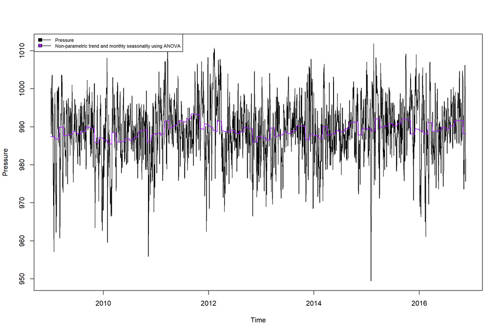

```r
gam1.fitted.ts = ts(fitted(gam1.fitted), freq = 365, start = c(2009,1))
plot(daily.pressure.train.ts,ylab="Pressure", col="black")
lines(gam1.fitted.ts, lwd=1.5,col="purple")
legend(x="topleft", legend=c("Pressure", "Non-parametric trend and monthly seasonality using ANOVA"), fill = c("black", "purple"), cex=0.7, lty=1)
```

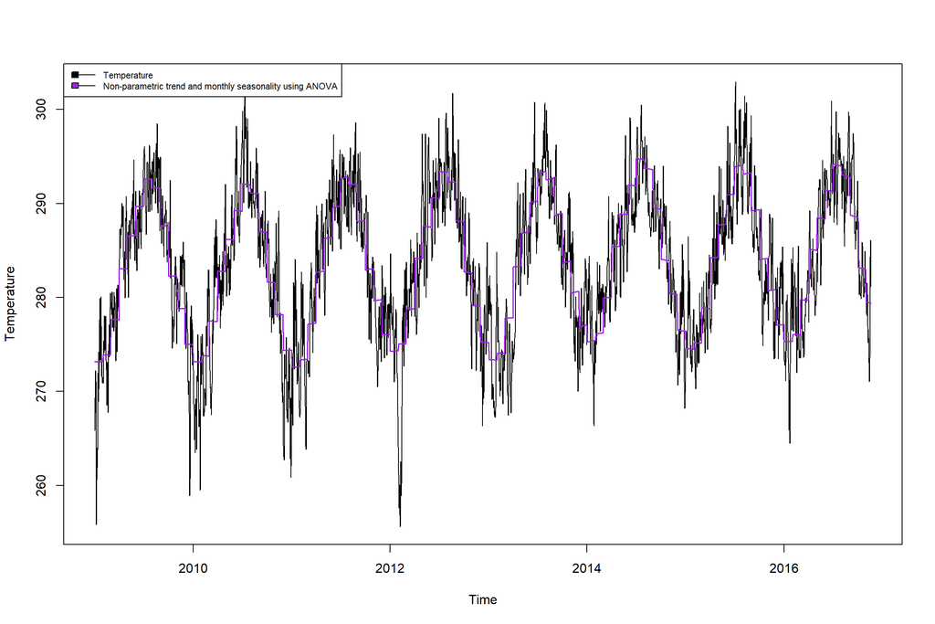

```r
gam2.fitted.ts = ts(fitted(gam2.fitted), freq = 365, start = c(2009,1))
plot(daily.temp.train.ts,ylab="Temperature", col="black")
lines(gam2.fitted.ts, lwd=1.5,col="purple")
legend(x="topleft", legend=c("Temperature", "Non-parametric trend and monthly seasonality using ANOVA"), fill = c("black", "purple"), cex=0.7, lty=1)
```

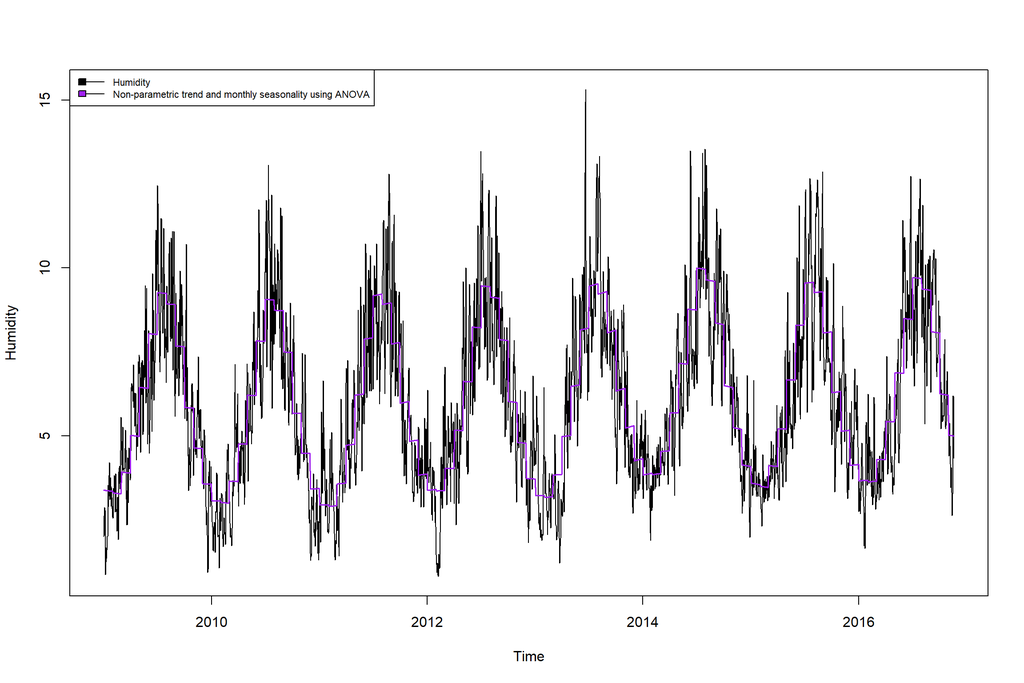

```r
gam3.fitted.ts = ts(fitted(gam3.fitted), freq = 365, start = c(2009,1))
plot(daily.humidity.train.ts,ylab="Humidity", col="black")
lines(gam3.fitted.ts, lwd=1.5,col="purple")
legend(x="topleft", legend=c("Humidity", "Non-parametric trend and monthly seasonality using ANOVA"), fill = c("black", "purple"), cex=0.7, lty=1)
```

*Response*: Looking at the plots above, we can see that for all 3 time series we were able to capture the main pattern, especially it is visible for temperature and humidity time series that have clear seasonality patterns.

### Residual Analysis

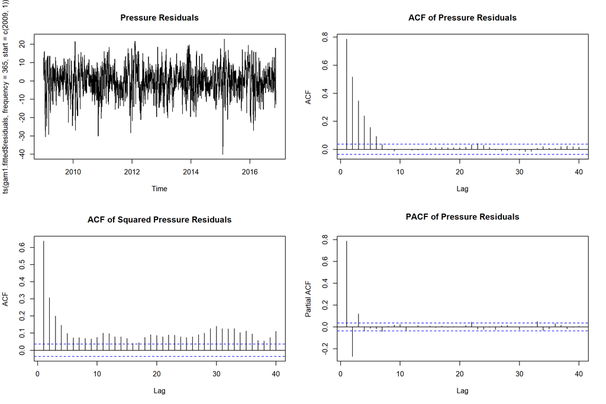

```r
par(mfrow=c(2,2))
ts.plot(ts(gam1.fitted$residuals, frequency = 365, start = c(2009,1)), main="Pressure Residuals")
acf(gam1.fitted$residuals, lag.max = 40, main="ACF of Pressure Residuals")
acf(gam1.fitted$residuals^2, lag.max = 40, main="ACF of Squared Pressure Residuals")
pacf(gam1.fitted$residuals, lag.max = 40, main="PACF of Pressure Residuals")
```

```r
adf.test(gam1.fitted$residuals, k=1)
```

```
##
##  Augmented Dickey-Fuller Test
##
## data:  gam1.fitted$residuals
## Dickey-Fuller = -23.051, Lag order = 1, p-value = 0.01
## alternative hypothesis: stationary
```

```r
adf.test(gam1.fitted$residuals, k=5)
```

```
##
##  Augmented Dickey-Fuller Test
##
## data:  gam1.fitted$residuals
## Dickey-Fuller = -16.966, Lag order = 5, p-value = 0.01
## alternative hypothesis: stationary
```

```r
kpss.test(gam1.fitted$residuals)
```

```
##
##  KPSS Test for Level Stationarity
##
## data:  gam1.fitted$residuals
## KPSS Level = 0.018621, Truncation lag parameter = 9, p-value = 0.1
```

*Response*: Looking at the time series plot variance seems to be somewhat constant, howevered acf of squared residuals shows some correlation. On the ACF plot we see that most of the values after lag 7 are within the confidence band, which indicates stationarity. Results of Augmented Dickey-Fuller Test and KPSS test also suggest stationary data. To conclude, based on time series plot, ACF plot and results of the test for stationarity we conclude that the residuals of the first model are stationary and there’s heteroscedasticity present.

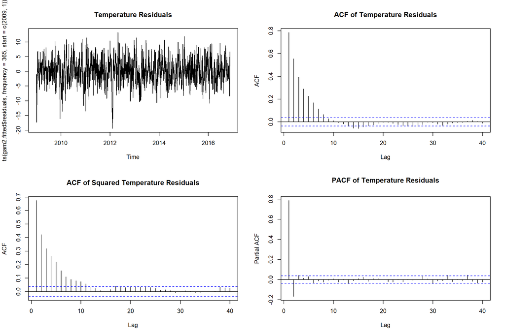

```r
par(mfrow=c(2,2))
ts.plot(ts(gam2.fitted$residuals, frequency = 365, start = c(2009,1)), main="Temperature Residuals")
acf(gam2.fitted$residuals, lag.max = 40, main="ACF of Temperature Residuals")
acf(gam2.fitted$residuals^2, lag.max = 40, main="ACF of Squared Temperature Residuals")
pacf(gam2.fitted$residuals, lag.max = 40, main="PACF of Temperature Residuals")
```

```r
adf.test(gam2.fitted$residuals, k=1)
```

```
##
##  Augmented Dickey-Fuller Test
##
## data:  gam2.fitted$residuals
## Dickey-Fuller = -20.712, Lag order = 1, p-value = 0.01
## alternative hypothesis: stationary
```

```r
adf.test(gam2.fitted$residuals, k=5)
```

```
##
##  Augmented Dickey-Fuller Test
##
## data:  gam2.fitted$residuals
## Dickey-Fuller = -15.875, Lag order = 5, p-value = 0.01
## alternative hypothesis: stationary
```

```r
kpss.test(gam2.fitted$residuals)
```

```
##
##  KPSS Test for Level Stationarity
##
## data:  gam2.fitted$residuals
## KPSS Level = 0.013906, Truncation lag parameter = 9, p-value = 0.1
```

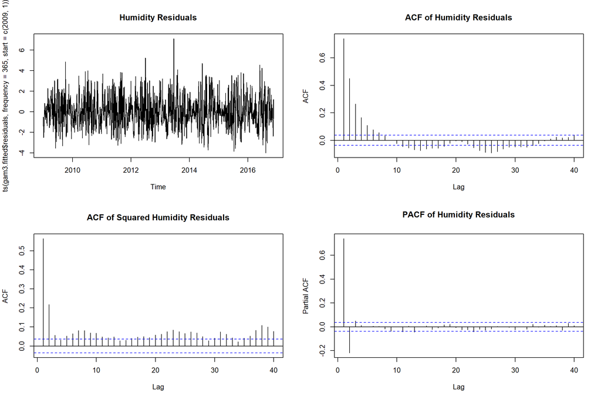

```r
par(mfrow=c(2,2))
ts.plot(ts(gam3.fitted$residuals, frequency = 365, start = c(2009,1)), main="Humidity Residuals")
acf(gam3.fitted$residuals, lag.max = 40, main="ACF of Humidity Residuals")
acf(gam3.fitted$residuals^2, lag.max = 40, main="ACF of Squared Humidity Residuals")
pacf(gam3.fitted$residuals, lag.max = 40, main="PACF of Humidity Residuals")
```

```r
adf.test(gam3.fitted$residuals, k=1)
```

```
##
##  Augmented Dickey-Fuller Test
##
## data:  gam3.fitted$residuals
## Dickey-Fuller = -24.121, Lag order = 1, p-value = 0.01
## alternative hypothesis: stationary
```

```r
adf.test(gam3.fitted$residuals, k=5)
```

```
##
##  Augmented Dickey-Fuller Test
##
## data:  gam3.fitted$residuals
## Dickey-Fuller = -17.022, Lag order = 5, p-value = 0.01
## alternative hypothesis: stationary
```

```r
kpss.test(gam3.fitted$residuals)
```

```
##
##  KPSS Test for Level Stationarity
##
## data:  gam3.fitted$residuals
## KPSS Level = 0.010698, Truncation lag parameter = 9, p-value = 0.1
```

*Response*: Looking at the time series plot and ACF plot of Squared residuals we conclude that the variance isn’t constant. On the ACF plot we see a seasonal pattern, which indicates non stationarity. However, results of Augmented Dickey-Fuller Test and KPSS both test suggest stationary data. So there is not enough evidence to indicate non stationary data. To conclude, based on time series plot, ACF plot and results of the test for stationarity we conclude that the residuals of the third model are close to stationary, but we cannot say for sure. There’s also heteroscedasticity in the residuals.

### Predictions

#### Pressure

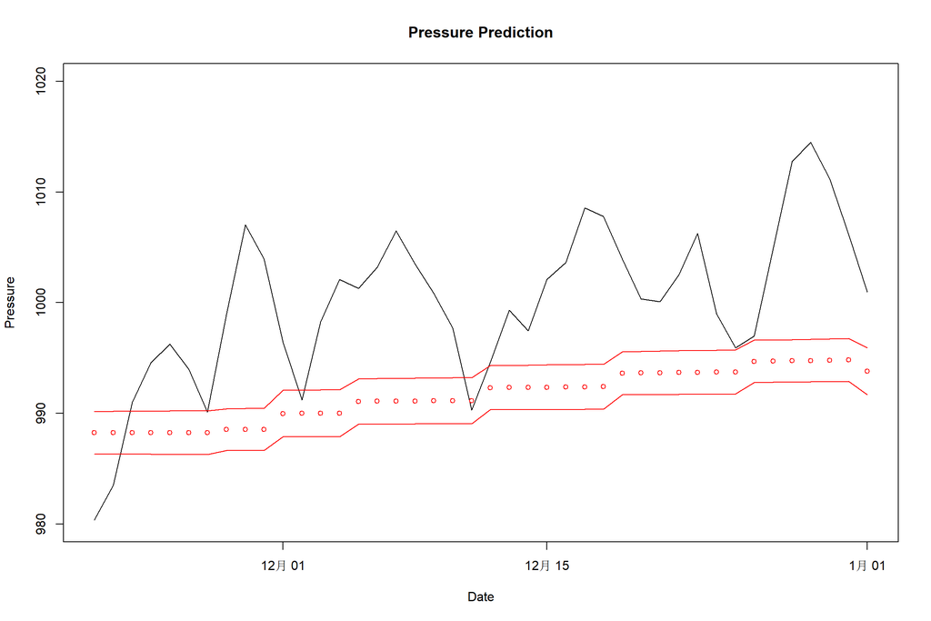

```r
prediction.h.gam <- c()
prediction.p.gam <- c()
prediction.t.gam <- c()

for (i in 1:6) {
  data <- daily.training.data
  new.data <- daily.testing.data[c((1 + (i - 1)*7):(i*7)),]
  if (i >= 2) {
    data <- rbind(data, daily.testing.data[c(1:((i - 1)*7)),])
  }
  tps <- c(1:nrow(data.daily))
  tps <- c(tps - min(tps))/max(tps)
  data$tps <- tps[1:nrow(data)]
  new.data$tps <- tps[(nrow(data) + 1):(nrow(data) + 7)]

  gam.p <- gam(pressure ~ s(tps)+factor(month), data = data)
  predict.p <- predict(gam.p, new.data, se.fit = TRUE)
  lb <- predict.p$fit - 1.96 * predict.p$se.fit
  ub <- predict.p$fit + 1.96 * predict.p$se.fit
  temp <- data.frame('prediction' = predict.p$fit, 'lower' = lb, 'upper' = ub)
  prediction.p.gam <- rbind(prediction.p.gam,temp)

  gam.t <- gam(temperature ~ s(tps)+factor(month), data = data)
  predict.t <- predict(gam.t, new.data, se.fit = TRUE)
  lb <- predict.t$fit - 1.96 * predict.t$se.fit
  ub <- predict.t$fit + 1.96 * predict.t$se.fit
  temp <- data.frame('prediction' = predict.t$fit, 'lower' = lb, 'upper' = ub)
  prediction.t.gam <- rbind(prediction.t.gam,temp)

  gam.h <- gam(humidity ~ s(tps)+factor(month), data = data)
  predict.h <- predict(gam.h, new.data, se.fit = TRUE)
  lb <- predict.h$fit - 1.96 * predict.h$se.fit
  ub <- predict.h$fit + 1.96 * predict.h$se.fit
  temp <- data.frame('prediction' = predict.h$fit, 'lower' = lb, 'upper' = ub)
  prediction.h.gam <- rbind(prediction.h.gam,temp)
}

gam.prediction <- data.frame('date' = daily.testing.data$date,
                             'pressure' = prediction.p.gam,
                             'temperature' = prediction.t.gam,
                             'humidity' = prediction.h.gam,
                             'month' = daily.testing.data$month)

plot(daily.testing.data$date, daily.testing.data$pressure, type = 'l', ylim = c(980,1020), main = 'Pressure Prediction', ylab = 'Pressure', xlab = 'Date')
points(daily.testing.data$date, prediction.p.gam$prediction, col = 'red', ylim = c(268,285),ylab = '', pch = 1, cex = 0.8, xlab = 'Date')
lines(daily.testing.data$date, prediction.p.gam$lower, col = 'red', ylim = c(268,285),ylab = '', pch = 1, cex = 0.8, xlab = 'Date')
lines(daily.testing.data$date, prediction.p.gam$upper, col = 'red', ylim = c(268,285),ylab = '', pch = 1, cex = 0.8, xlab = 'Date')
```

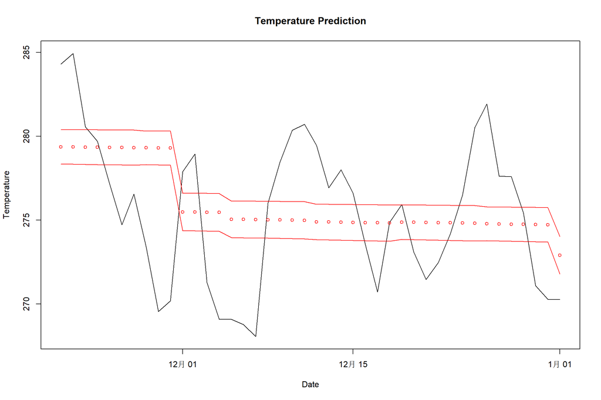

```r
plot(daily.testing.data$date, daily.testing.data$temperature, ylim = c(268,285), main = 'Temperature Prediction', ylab = 'Temperature', type = 'l', xlab = 'Date')
points(daily.testing.data$date, prediction.t.gam$prediction, col = 'red', ylim = c(268,285),ylab = '', pch = 1, cex = 0.8, xlab = 'Date')
lines(daily.testing.data$date, prediction.t.gam$lower, col = 'red', ylim = c(268,285),ylab = '', pch = 1, cex = 0.8, xlab = 'Date')
lines(daily.testing.data$date, prediction.t.gam$upper, col = 'red', ylim = c(268,285),ylab = '', pch = 1, cex = 0.8, xlab = 'Date')
```

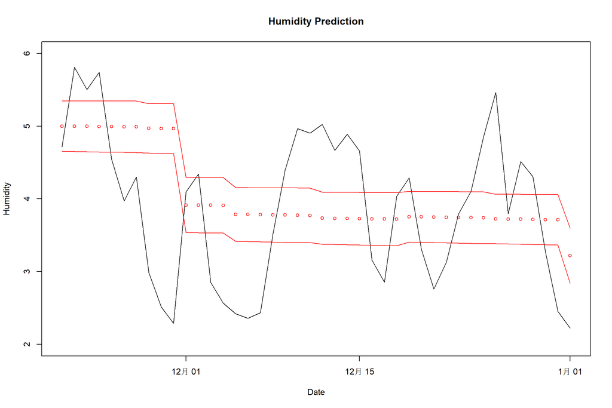

```r
plot(daily.testing.data$date, daily.testing.data$humidity, ylim = c(2,6), main = 'Humidity Prediction',ylab = 'Humidity', type = 'l', xlab = 'Date')
points(daily.testing.data$date, prediction.h.gam$prediction, col = 'red', ylim = c(268,285),ylab = '', pch = 1, cex = 0.8, xlab = 'Date')
lines(daily.testing.data$date, prediction.h.gam$lower, col = 'red', ylim = c(268,285),ylab = '', pch = 1, cex = 0.8, xlab = 'Date')
lines(daily.testing.data$date, prediction.h.gam$upper, col = 'red', ylim = c(268,285),ylab = '', pch = 1, cex = 0.8, xlab = 'Date')
```

## ARMA modeling

### Pressure

```r
nfit = length(daily.testing.date)
harmonic.train <- cbind(sin(daily.training.month*2*pi/12),cos(daily.training.month*2*pi/12))
harmonic.test <- cbind(sin(daily.testing.month*2*pi/12),cos(daily.testing.month*2*pi/12))
harmonic.all <- rbind(harmonic.train, harmonic.test)
```

```r
## Fit an ARMA model to the residuals

#Iterative function
test_modelA <- function(p,d,q,train.data){
  mod = Arima(train.data,order=c(p,d,q),xreg=as.matrix(harmonic.train))
  current.aic = AIC(mod)
  df = data.frame(p,d,q,current.aic)
  names(df) <- c("p","d","q","AIC")
  return(df)
}
```

```r
#orders = data.frame(Inf,Inf,Inf, Inf)
#names(orders) <- c("p","d","q","AIC")

#Orders for Arima for Pressure
#for (p in 0:9){
#    for (q in 0:9) {
#      for (d in 0:1) {
#          possibleError <- tryCatch(
#          orders<-rbind(orders,test_modelA(p,d,q,daily.pressure.train.ts)),
#          error=function(e) e
#          )
#          if(inherits(possibleError, "error")) next
#      }
#  }
#}
#orders <- orders[order(-orders$AIC),]
#tail(orders,5)
```

```r
arma.pressure <- Arima(daily.pressure.train.ts,order=c(4,1,6),xreg=as.matrix(harmonic.train))
arma.pressure
```

```
## Series: daily.pressure.train.ts
## Regression with ARIMA(4,1,6) errors
##
## Coefficients:
##          ar1      ar2     ar3     ar4      ma1     ma2      ma3      ma4
##       0.2212  -0.3910  0.0810  0.3321  -0.1713  0.0267  -0.2155  -0.5524
## s.e.  0.2714   0.2003  0.2358  0.1684   0.2713  0.1822   0.0969   0.1548
##           ma5     ma6    xreg1    xreg2
##       -0.1592  0.0746  -0.7215  -0.5604
## s.e.   0.0968  0.0282   0.5014   0.5009
##
## sigma^2 = 21.21:  log likelihood = -8475.3
## AIC=16976.6   AICc=16976.72   BIC=17054.14
```

```r
## compute the test statistics
testval <-
  as.numeric(arma.pressure$coef) / as.numeric(sqrt(diag(arma.pressure$var.coef)))

## print t-statistic
print(testval)
```

```
##  [1]  0.8152593 -1.9522950  0.3435232  1.9718865 -0.6316091  0.1468292
##  [7] -2.2234928 -3.5676878 -1.6447554  2.6449889 -1.4390825 -1.1187279
```

```r
## print p-values
print(2*(1-pnorm(abs(testval))))
```

```
##  [1] 0.4149239240 0.0509031915 0.7312049166 0.0486225699 0.5276423706
##  [6] 0.8832668581 0.0261825887 0.0003601453 0.1000202665 0.0081693603
## [11] 0.1501271583 0.2632562302
```

```r
## print significant coefficients for significance level 0.05
which(abs(testval)>qnorm((1-0.05/2)))
```

```
## [1]  4  7  8 10
```

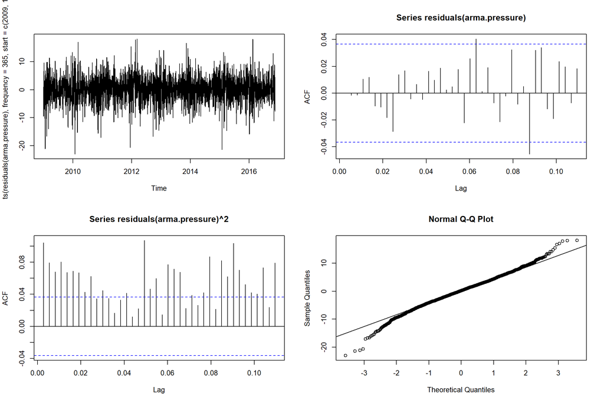

```r
par(mfrow=c(2,2))
ts.plot(ts(residuals(arma.pressure), frequency = 365, start = c(2009,1)))
acf(residuals(arma.pressure), lag.max = 40)
acf(residuals(arma.pressure)^2, lag.max = 40)
qqnorm(residuals(arma.pressure))
qqline(residuals(arma.pressure))
```

```r
#perform shapiro-wilk test
shapiro.test(residuals(arma.pressure))
```

```
##
##  Shapiro-Wilk normality test
##
## data:  residuals(arma.pressure)
## W = 0.99092, p-value = 1.518e-12
```

### Temperature

```r
#orders = data.frame(Inf,Inf,Inf, Inf)
#names(orders) <- c("p","d","q","AIC")

#Orders for Arima for Temperature
#for (p in 0:9){
#    for (q in 0:9) {
#      for (d in 0:1) {
#          possibleError <- tryCatch(
#          orders<-rbind(orders,test_modelA(p,d,q,daily.temp.train.ts)),
#          error=function(e) e
#          )
#          if(inherits(possibleError, "error")) next
#      }
#  }
#}
#orders <- orders[order(-orders$AIC),]
#tail(orders,5)
```

```r
arma.temp <- Arima(daily.temp.train.ts,order=c(8,1,4),xreg=as.matrix(harmonic.train))
arma.temp
```

```
## Series: daily.temp.train.ts
## Regression with ARIMA(8,1,4) errors
##
## Coefficients:
##          ar1     ar2     ar3      ar4     ar5      ar6      ar7      ar8
##       0.1720  1.2370  0.1585  -0.7318  0.2123  -0.0116  -0.0159  -0.0406
## s.e.  0.0219  0.0255  0.0304   0.0324  0.0303   0.0300   0.0203   0.0200
##           ma1      ma2      ma3     ma4    xreg1    xreg2
##       -0.1901  -1.4708  -0.2656  0.9354  -1.0227  -1.1964
## s.e.   0.0126   0.0167   0.0091  0.0181   0.6942   0.7803
##
## sigma^2 = 6.216:  log likelihood = -6706.31
## AIC=13442.62   AICc=13442.79   BIC=13532.09
```

```r
## compute the test statistics
testval <-
  as.numeric(arma.temp$coef) / as.numeric(sqrt(diag(arma.temp$var.coef)))

## print t-statistic
print(testval)
```

```
##  [1]   7.8366871  48.4151490   5.2090081 -22.5782888   6.9966463  -0.3871780
##  [7]  -0.7826786  -2.0298156 -15.1271815 -88.0552745 -29.1656596  51.6192042
## [13]  -1.4732966  -1.5332244
```

```r
## print p-values
print(2*(1-pnorm(abs(testval))))
```

```
##  [1] 4.662937e-15 0.000000e+00 1.898528e-07 0.000000e+00 2.621681e-12
##  [6] 6.986245e-01 4.338159e-01 4.237528e-02 0.000000e+00 0.000000e+00
## [11] 0.000000e+00 0.000000e+00 1.406711e-01 1.252206e-01
```

```r
## print significant coefficients for significance level 0.05
which(abs(testval)>qnorm((1-0.05/2)))
```

```
##  [1]  1  2  3  4  5  8  9 10 11 12
```

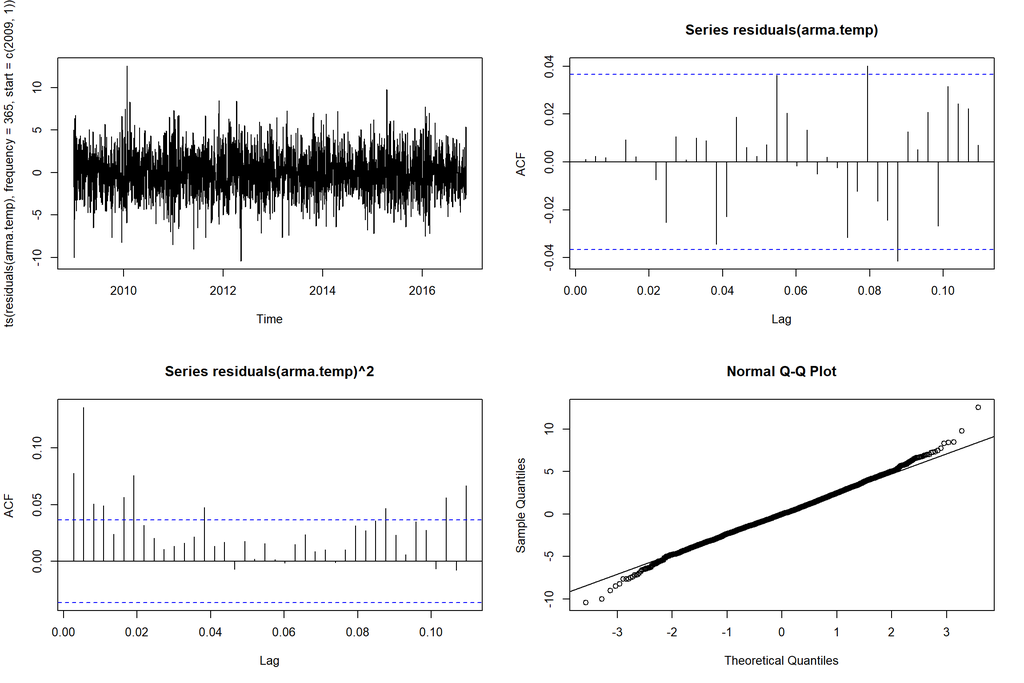

```r
par(mfrow=c(2,2))
ts.plot(ts(residuals(arma.temp), frequency = 365, start = c(2009,1)))
acf(residuals(arma.temp), lag.max = 40)
acf(residuals(arma.temp)^2, lag.max = 40)
qqnorm(residuals(arma.temp))
qqline(residuals(arma.temp))
```

```r
#perform shapiro-wilk test
shapiro.test(residuals(arma.temp))
```

```
##
##  Shapiro-Wilk normality test
##
## data:  residuals(arma.temp)
## W = 0.99718, p-value = 3.661e-05
```

### Humidity

```r
#Orders for Arima for Humidity
#orders = data.frame(Inf,Inf,Inf, Inf)
#names(orders) <- c("p","d","q","AIC")

#for (p in 0:9){
#    for (q in 0:9) {
#      for (d in 0:1) {
#          possibleError <- tryCatch(
#          orders<-rbind(orders,test_modelA(p,d,q,daily.humidity.train.ts)),
#          error=function(e) e
#          )
#          if(inherits(possibleError, "error")) next
#      }
#  }
#}
#orders <- orders[order(-orders$AIC),]
#tail(orders,5)
```

```r
arma.humidity <- Arima(daily.humidity.train.ts,order=c(5,0,1),xreg=as.matrix(harmonic.train))
arma.humidity
```

```
## Series: daily.humidity.train.ts
## Regression with ARIMA(5,0,1) errors
##
## Coefficients:
##          ar1      ar2     ar3      ar4      ar5      ma1  intercept    xreg1
##       1.8892  -1.1621  0.3122  -0.0360  -0.0080  -0.9362     5.9798  -1.2063
## s.e.  0.0233   0.0418  0.0452   0.0402   0.0198   0.0175     0.2335   0.2896
##         xreg2
##       -1.3099
## s.e.   0.3215
##
## sigma^2 = 0.8555:  log likelihood = -3856.68
## AIC=7733.36   AICc=7733.44   BIC=7793.01
```

```r
## compute the test statistics
testval <-
  as.numeric(arma.humidity$coef) / as.numeric(sqrt(diag(arma.humidity$var.coef)))

## print t-statistic
print(testval)
```

```
## [1]  81.0647787 -27.7964438   6.9121575  -0.8957076  -0.4027429 -53.3697661
## [7]  25.6134400  -4.1651096  -4.0743504
```

```r
## print p-values
print(2*(1-pnorm(abs(testval))))
```

```
## [1] 0.000000e+00 0.000000e+00 4.773293e-12 3.704090e-01 6.871373e-01
## [6] 0.000000e+00 0.000000e+00 3.112030e-05 4.614296e-05
```

```r
## print significant coefficients for significance level 0.05
which(abs(testval)>qnorm((1-0.05/2)))
```

```
## [1] 1 2 3 6 7 8 9
```

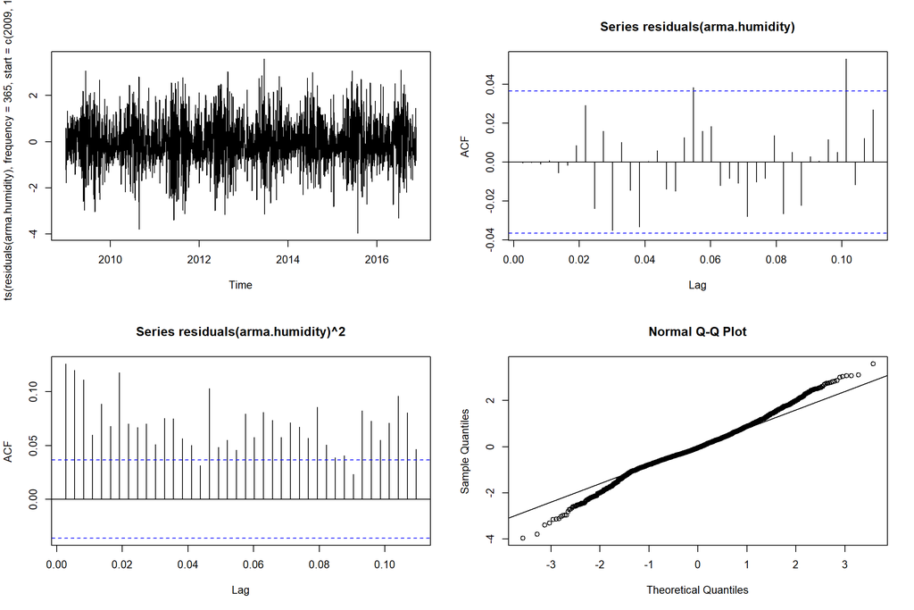

```r
par(mfrow=c(2,2))
ts.plot(ts(residuals(arma.humidity), frequency = 365, start = c(2009,1)))
acf(residuals(arma.humidity), lag.max = 40)
acf(residuals(arma.humidity)^2, lag.max = 40)
qqnorm(residuals(arma.humidity))
qqline(residuals(arma.humidity))
```

```r
#perform shapiro-wilk test
shapiro.test(residuals(arma.humidity))
```

```
##
##  Shapiro-Wilk normality test
##
## data:  residuals(arma.humidity)
## W = 0.98891, p-value = 3.391e-14
```

### Results

For all 3 models we see the similar results: 1) ACF plot of residuals indicates that the residuals aren’t correlated 2) ACF plot of Squared residuals indicates that the squared residuals are correlated, so we conclude that heteroskedasticity is present in the residuals. 3) Shapiro-Wilk normality test shows that the residuals are not normally distributed because it rejects the null hypothesis of normal distribution. The QQ plot also shows heavier tails than for normal distribution. We conclude that the residuals does not follow normal distribution, which is required for model fitting using MLE. We conclude that our models aren’t the good fit.

### Prediction

```r
prediction.p.arima <- data.frame(Inf, Inf, Inf)
names(prediction.p.arima) <- c('prediction', 'lower', 'upper')
prediction.t.arima <- data.frame(Inf, Inf, Inf)
names(prediction.t.arima) <- c('prediction', 'lower', 'upper')
prediction.h.arima <- data.frame(Inf, Inf, Inf)
names(prediction.h.arima) <- c('prediction', 'lower', 'upper')

for (i in 1:6) {
  data <- daily.training.data
  new.xreg <- harmonic.test[(1 + (i - 1)*7): (i*7),]
  if (i >= 2) {
    data <- rbind(data, daily.testing.data[c(1:((i - 1)*7)),])
  }

  arma.p <- Arima(data$pressure,order=c(4,1,6),
                  xreg=as.matrix(harmonic.all[1:nrow(data),]))
  arma.pred.p <- predict(arma.p, n.ahead = 7, newxreg = as.matrix(new.xreg))

  lb <- arma.pred.p$pred - 1.96 * arma.pred.p$se
  ub <- arma.pred.p$pred + 1.96 * arma.pred.p$se
  temp <- data.frame('prediction' = arma.pred.p$pred, 'lower' = lb, 'upper' = ub)
  prediction.p.arima <- rbind(prediction.p.arima, temp)

  arma.t <- Arima(data$temperature,order=c(8,1,4),
                  xreg=as.matrix(harmonic.all[1:nrow(data),]))
  arma.pred.t <- predict(arma.t, n.ahead = 7, newxreg = as.matrix(new.xreg))

  lb <- arma.pred.t$pred - 1.96 * arma.pred.t$se
  ub <- arma.pred.t$pred + 1.96 * arma.pred.t$se
  temp <- data.frame('prediction' = arma.pred.t$pred, 'lower' = lb, 'upper' = ub)
  prediction.t.arima <- rbind(prediction.t.arima, temp)

  arma.h <- Arima(data$humidity,order=c(5,0,1),
                  xreg=as.matrix(harmonic.all[1:nrow(data),]))
  arma.pred.h <- predict(arma.h, n.ahead = 7, newxreg = as.matrix(new.xreg))

  lb <- arma.pred.h$pred - 1.96 * arma.pred.h$se
  ub <- arma.pred.h$pred + 1.96 * arma.pred.h$se
  temp <- data.frame('prediction' = arma.pred.h$pred, 'lower' = lb, 'upper' = ub)
  prediction.h.arima <- rbind(prediction.h.arima, temp)
}
prediction.p.arima <- prediction.p.arima[-1,]
prediction.p.arima$date <- daily.testing.data$date

prediction.t.arima <- prediction.t.arima[-1,]
prediction.t.arima$date <- daily.testing.data$date

prediction.h.arima <- prediction.h.arima[-1,]
prediction.h.arima$date <- daily.testing.data$date

armax.prediction <- list(prediction.p.arima, prediction.t.arima, prediction.h.arima)
# save(armax.prediction, file = 'armax-prediction.RData')
```

### Prediction Plots

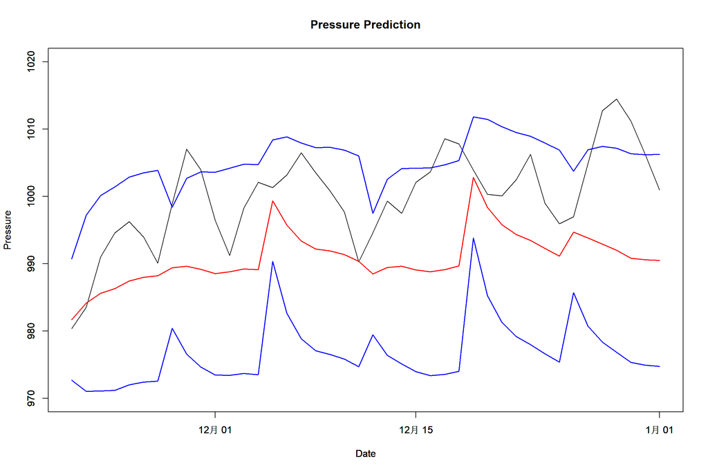

```r
load('armax-prediction.RData')
prediction.p.armax <- armax.prediction[[1]]
prediction.t.armax <- armax.prediction[[2]]
prediction.h.armax <- armax.prediction[[3]]


plot(daily.testing.data$date, daily.testing.data$pressure, type = 'l', ylim = c(970,1020), main = 'Pressure Prediction', ylab = 'Pressure', xlab = 'Date')
par(new = T)
plot(daily.testing.data$date, prediction.p.armax$prediction, type = 'l', col = 'red', ylim = c(970,1020), ylab = '', lwd = 1.5, xlab = 'Date')
par(new = T)
plot(daily.testing.data$date, prediction.p.armax$lower, type = 'l', col = 'blue', ylim = c(970,1020), ylab = '', lwd = 1.5, xlab = 'Date')
par(new = T)
plot(daily.testing.data$date, prediction.p.armax$upper, type = 'l', col = 'blue', ylim = c(970,1020), ylab = '', lwd = 1.5, xlab = 'Date')
```

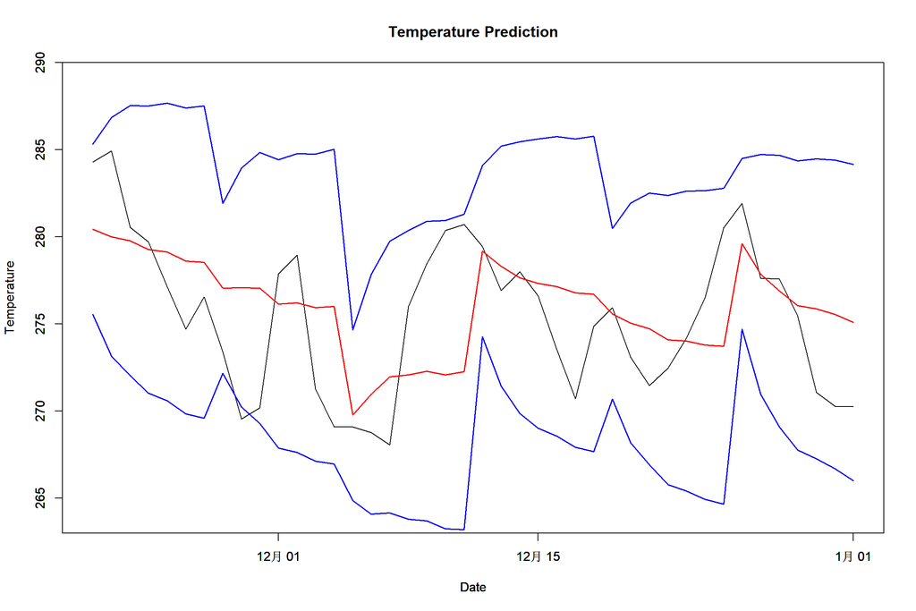

```r
plot(daily.testing.data$date, daily.testing.data$temperature, type = 'l', ylim = c(264,289), main = 'Temperature Prediction', ylab = 'Temperature', xlab = 'Date')
par(new = T)
plot(daily.testing.data$date, prediction.t.armax$prediction, type = 'l', col = 'red', ylim = c(264,289), ylab = '', lwd = 1.5, xlab = 'Date')
par(new = T)
plot(daily.testing.data$date, prediction.t.armax$lower, type = 'l', col = 'blue', ylim = c(264,289), ylab = '', lwd = 1.5, xlab = 'Date')
par(new = T)
plot(daily.testing.data$date, prediction.t.armax$upper, type = 'l', col = 'blue', ylim = c(264,289), ylab = '', lwd = 1.5, xlab = 'Date')
```

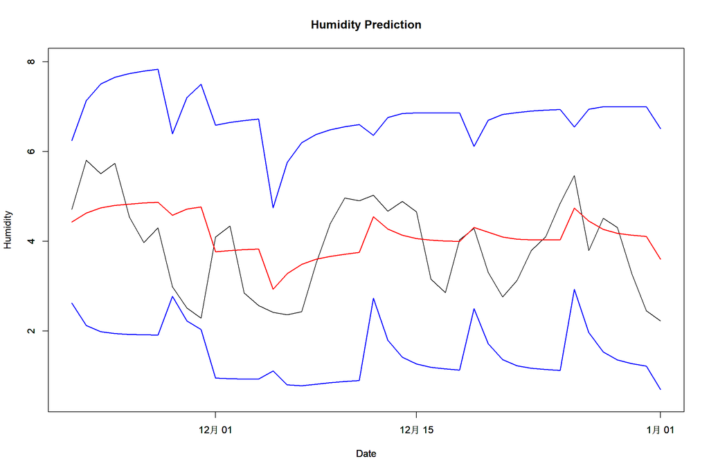

```r
plot(daily.testing.data$date, daily.testing.data$humidity, type = 'l', ylim = c(0.5,8), main = 'Humidity Prediction', ylab = 'Humidity', xlab = 'Date')
par(new = T)
plot(daily.testing.data$date, prediction.h.armax$prediction, type = 'l', col = 'red', ylim = c(0.5,8), ylab = '', lwd = 1.5, xlab = 'Date')
par(new = T)
plot(daily.testing.data$date, prediction.h.armax$lower, type = 'l', col = 'blue', ylim = c(0.5,8), ylab = '', lwd = 1.5, xlab = 'Date')
par(new = T)
plot(daily.testing.data$date, prediction.h.armax$upper, type = 'l', col = 'blue', ylim = c(0.5,8), ylab = '', lwd = 1.5, xlab = 'Date')
```

## ARMA-GARCH for modeling pressure

```r
# We take order of ARMA equal to (4,1,6)
# Find order for GARCH
test_modelAGG <- function(m,n){
    spec = ugarchspec(variance.model=list(garchOrder=c(m,n)),
                      mean.model=list(armaOrder=c(4,1,6),
                                      external.regressors = as.matrix(harmonic.train),
                                      include.mean=T), distribution.model="std")
    fit = ugarchfit(spec, daily.pressure.train.ts, solver = 'hybrid')
    current.aic = infocriteria(fit)[1]
    df = data.frame(m,n,current.aic)
    names(df) <- c("m","n","AIC")
    return(df)
}

ordersAGG = data.frame(Inf,Inf,Inf)
names(ordersAGG) <- c("m","n","AIC")

for (m in 0:2){
    for (n in 0:2){
        possibleError <- tryCatch(
            ordersAGG<-rbind(ordersAGG,test_modelAGG(m,n)),
            error=function(e) e
        )
        if(inherits(possibleError, "error")) next
    }
}
ordersAGG <- ordersAGG[order(-ordersAGG$AIC),]
tail(ordersAGG)
```

```r
# Update ARMA using GARCH = (2,2)
test_modelAGA <- function(p,q){
    spec = ugarchspec(variance.model=list(garchOrder=c(1,1)),
                      mean.model=list(armaOrder=c(p,q),
                                      external.regressors = as.matrix(harmonic.train),
                                      include.mean=T),
                      distribution.model="std")
    fit = ugarchfit(spec, daily.pressure.train.ts, solver = 'hybrid')
    current.aic = infocriteria(fit)[1]
    df = data.frame(p,q,current.aic)
    names(df) <- c("p","q","AIC")
    return(df)
}

ordersAGA = data.frame(Inf,Inf,Inf)
names(ordersAGA) <- c("p","q","AIC")
for (p in 0:7){
    for (q in 0:7){1
              ordersAGA<-rbind(ordersAGA,test_modelAGA(p,q))
    }
}
ordersAGA <- ordersAGA[order(-ordersAGA$AIC),]
tail(ordersAGA)
```

```r
# Update order for GARCH using ARMA (6,5s)
test_modelAGG <- function(m,n){
    spec = ugarchspec(variance.model=list(garchOrder=c(m,n)),
                      mean.model=list(armaOrder=c(6,5),
                                      external.regressors = as.matrix(harmonic.train),
                                      include.mean=T), distribution.model="std")
    fit = ugarchfit(spec, daily.pressure.train.ts, solver = 'hybrid')
    current.aic = infocriteria(fit)[1]
    df = data.frame(m,n,current.aic)
    names(df) <- c("m","n","AIC")
    return(df)
}

ordersAGG = data.frame(Inf,Inf,Inf)
names(ordersAGG) <- c("m","n","AIC")

for (m in 0:2){
    for (n in 0:2){
        possibleError <- tryCatch(
            ordersAGG<-rbind(ordersAGG,test_modelAGG(m,n)),
            error=function(e) e
        )
        if(inherits(possibleError, "error")) next
    }
}
ordersAGG <- ordersAGG[order(-ordersAGG$AIC),]
tail(ordersAGG)
```

[output not shown]

```r
spec.1 = ugarchspec(variance.model=list(garchOrder=c(1,1)),
                 mean.model=list(armaOrder=c(6,5),
                                 external.regressors = as.matrix(harmonic.train),
                                  include.mean=T), distribution.model="std")
pressure.arma.garch<-ugarchfit(spec.1,daily.pressure.train.ts,solver='hybrid')
pressure.arma.garch
```

```
##
## *---------------------------------*
## *          GARCH Model Fit        *
## *---------------------------------*
##
## Conditional Variance Dynamics
## -----------------------------------
## GARCH Model  : sGARCH(1,1)
## Mean Model   : ARFIMA(6,0,5)
## Distribution : std
##
## Optimal Parameters
## ------------------------------------
##          Estimate  Std. Error     t value Pr(>|t|)
## mu     989.530350    0.060740  16291.1564 0.000000
## ar1      1.176996    0.000082  14298.9440 0.000000
## ar2     -1.388604    0.000097 -14245.9261 0.000000
## ar3      0.751087    0.000054  13967.5002 0.000000
## ar4     -0.153121    0.000021  -7322.7948 0.000000
## ar5      0.131998    0.000020   6734.6398 0.000000
## ar6     -0.047959    0.000012  -4102.3256 0.000000
## ma1     -0.120052    0.000073  -1651.0451 0.000000
## ma2      0.825754    0.000101   8159.1504 0.000000
## ma3      0.343660    0.000069   5015.1708 0.000000
## ma4      0.095019    0.000087   1094.5026 0.000000
## ma5     -0.057379    0.000060   -961.1567 0.000000
## mxreg1  -0.710602    0.093836     -7.5728 0.000000
## mxreg2   0.340310    0.054176      6.2815 0.000000
## omega    0.396509    0.242403      1.6357 0.101893
## alpha1   0.064617    0.026339      2.4533 0.014155
## beta1    0.917282    0.035673     25.7139 0.000000
## shape   12.012321    2.343509      5.1258 0.000000
##
## Robust Standard Errors:
##          Estimate  Std. Error     t value Pr(>|t|)
## mu     989.530350    1.459151   678.15487 0.000000
## ar1      1.176996    0.001376   855.31246 0.000000
## ar2     -1.388604    0.000818 -1698.30087 0.000000
## ar3      0.751087    0.000574  1308.22530 0.000000
## ar4     -0.153121    0.000299  -512.11561 0.000000
```

[output cut: 79 more lines]

```
## Negative Sign Bias  1.5434 0.122851
## Positive Sign Bias  0.1277 0.898433
## Joint Effect       13.1897 0.004244 ***
##
##
## Adjusted Pearson Goodness-of-Fit Test:
## ------------------------------------
##   group statistic p-value(g-1)
## 1    20     24.54      0.17614
## 2    30     33.50      0.25800
## 3    40     42.17      0.33563
## 4    50     63.43      0.08065
##
##
## Elapsed time : 3.140154
```

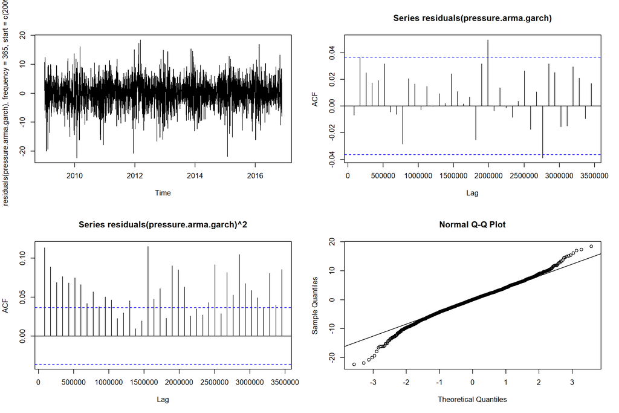

```r
par(mfrow=c(2,2))
ts.plot(ts(residuals(pressure.arma.garch), frequency = 365, start = c(2009,1)))
acf(residuals(pressure.arma.garch), lag.max = 40)
acf(residuals(pressure.arma.garch)^2, lag.max = 40)
qqnorm(residuals(pressure.arma.garch))
qqline(residuals(pressure.arma.garch))
```

## ARMA-GARCH for modeling temperature

```r
# We take order of ARMA equal to (8,1,4)
# Find order for GARCH
test_modelAGG <- function(m,n){
    spec = ugarchspec(variance.model=list(garchOrder=c(m,n)),
                      mean.model=list(armaOrder=c(8,1,4),
                                      external.regressors = as.matrix(harmonic.train),
                                      include.mean=T), distribution.model="std")
    fit = ugarchfit(spec, daily.temp.train.ts, solver = 'hybrid')
    current.aic = infocriteria(fit)[1]
    df = data.frame(m,n,current.aic)
    names(df) <- c("m","n","AIC")
    return(df)
}

ordersAGG = data.frame(Inf,Inf,Inf)
names(ordersAGG) <- c("m","n","AIC")

for (m in 0:2){
    for (n in 0:2){
        possibleError <- tryCatch(
            ordersAGG<-rbind(ordersAGG,test_modelAGG(m,n)),
            error=function(e) e
        )
        if(inherits(possibleError, "error")) next
    }
}
ordersAGG <- ordersAGG[order(-ordersAGG$AIC),]
tail(ordersAGG)
```

```r
# Update ARMA using GARCH = (2,0)
test_modelAGA <- function(p,q){
    spec = ugarchspec(variance.model=list(garchOrder=c(2,0)),
                      mean.model=list(armaOrder=c(p,q),
                                      external.regressors = as.matrix(harmonic.train),
                                      include.mean=T),
                      distribution.model="std")
    fit = ugarchfit(spec, daily.temp.train.ts, solver = 'hybrid')
    current.aic = infocriteria(fit)[1]
    df = data.frame(p,q,current.aic)
    names(df) <- c("p","q","AIC")
    return(df)
}

ordersAGA = data.frame(Inf,Inf,Inf)
names(ordersAGA) <- c("p","q","AIC")
for (p in 0:7){
    for (q in 0:7){
        possibleError <- tryCatch(
            ordersAGA<-rbind(ordersAGA,test_modelAGA(p,q)),
            error=function(e) e
        )
        if(inherits(possibleError, "error")) next
    }
}
ordersAGA <- ordersAGA[order(-ordersAGA$AIC),]
tail(ordersAGA)
```

```r
# We take order of ARMA equal to (6,5)
# Find order for GARCH
test_modelAGG <- function(m,n){
    spec = ugarchspec(variance.model=list(garchOrder=c(m,n)),
                      mean.model=list(armaOrder=c(6,5),
                                      external.regressors = as.matrix(harmonic.train),
                                      include.mean=T), distribution.model="std")
    fit = ugarchfit(spec, daily.temp.train.ts, solver = 'hybrid')
    current.aic = infocriteria(fit)[1]
    df = data.frame(m,n,current.aic)
    names(df) <- c("m","n","AIC")
    return(df)
}

ordersAGG = data.frame(Inf,Inf,Inf)
names(ordersAGG) <- c("m","n","AIC")

for (m in 0:2){
    for (n in 0:2){
        possibleError <- tryCatch(
            ordersAGG<-rbind(ordersAGG,test_modelAGG(m,n)),
            error=function(e) e
        )
        if(inherits(possibleError, "error")) next
    }
}
ordersAGG <- ordersAGG[order(-ordersAGG$AIC),]
tail(ordersAGG)
```

```r
# Update ARMA using GARCH = (1,1)
test_modelAGA <- function(p,q){
    spec = ugarchspec(variance.model=list(garchOrder=c(1,1)),
                      mean.model=list(armaOrder=c(p,q),
                                      external.regressors = as.matrix(harmonic.train),
                                      include.mean=T),
                      distribution.model="std")
    fit = ugarchfit(spec, daily.temp.train.ts, solver = 'hybrid')
    current.aic = infocriteria(fit)[1]
    df = data.frame(p,q,current.aic)
    names(df) <- c("p","q","AIC")
    return(df)
}

ordersAGA = data.frame(Inf,Inf,Inf)
names(ordersAGA) <- c("p","q","AIC")
for (p in 0:7){
    for (q in 0:7){
        possibleError <- tryCatch(
            ordersAGA<-rbind(ordersAGA,test_modelAGA(p,q)),
            error=function(e) e
        )
        if(inherits(possibleError, "error")) next
    }
}
ordersAGA <- ordersAGA[order(-ordersAGA$AIC),]
tail(ordersAGA)
```

The final iteration shows that the optimal orders for modeling the temperature are (6,5)x(1,1).

```r
spec.2 = ugarchspec(variance.model=list(garchOrder=c(1,1)),
                 mean.model=list(armaOrder=c(6,5),
                                 external.regressors = as.matrix(harmonic.train),
                                  include.mean=T), distribution.model="std")
temp.arma.garch<-ugarchfit(spec.2,daily.temp.train.ts,solver='hybrid')
temp.arma.garch
```

```
##
## *---------------------------------*
## *          GARCH Model Fit        *
## *---------------------------------*
##
## Conditional Variance Dynamics
## -----------------------------------
## GARCH Model  : sGARCH(1,1)
## Mean Model   : ARFIMA(6,0,5)
## Distribution : std
##
## Optimal Parameters
## ------------------------------------
##          Estimate  Std. Error   t value Pr(>|t|)
## mu     271.263756    1.427962 189.96568 0.000000
## ar1      0.570379    0.032672  17.45762 0.000000
## ar2     -0.022865    0.072061  -0.31731 0.751012
## ar3      0.701241    0.064445  10.88130 0.000000
## ar4      0.096010    0.052341   1.83433 0.066605
## ar5     -0.467314    0.070935  -6.58788 0.000000
## ar6      0.119932    0.010027  11.96105 0.000000
## ma1      0.433356    0.038309  11.31219 0.000000
## ma2      0.231300    0.032419   7.13468 0.000000
## ma3     -0.522527    0.037746 -13.84321 0.000000
## ma4     -0.658227    0.018712 -35.17639 0.000000
## ma5     -0.031872    0.021406  -1.48896 0.136499
## mxreg1  -1.277203    0.677287  -1.88576 0.059327
## mxreg2  -1.251830    0.795318  -1.57400 0.115487
## omega    0.948806    0.250206   3.79210 0.000149
## alpha1   0.107232    0.020685   5.18400 0.000000
## beta1    0.740227    0.053320  13.88270 0.000000
## shape   21.347142    7.009966   3.04526 0.002325
##
## Robust Standard Errors:
##          Estimate  Std. Error   t value Pr(>|t|)
## mu     271.263756    2.114351 128.29649 0.000000
## ar1      0.570379    0.041612  13.70708 0.000000
## ar2     -0.022865    0.067598  -0.33826 0.735169
## ar3      0.701241    0.087749   7.99143 0.000000
## ar4      0.096010    0.065548   1.46474 0.142993
```

[output cut: 79 more lines]

```
## Negative Sign Bias 0.09258 0.9262
## Positive Sign Bias 0.10675 0.9150
## Joint Effect       2.43674 0.4868
##
##
## Adjusted Pearson Goodness-of-Fit Test:
## ------------------------------------
##   group statistic p-value(g-1)
## 1    20     25.00       0.1605
## 2    30     33.04       0.2760
## 3    40     34.80       0.6617
## 4    50     47.45       0.5361
##
##
## Elapsed time : 2.251366
```

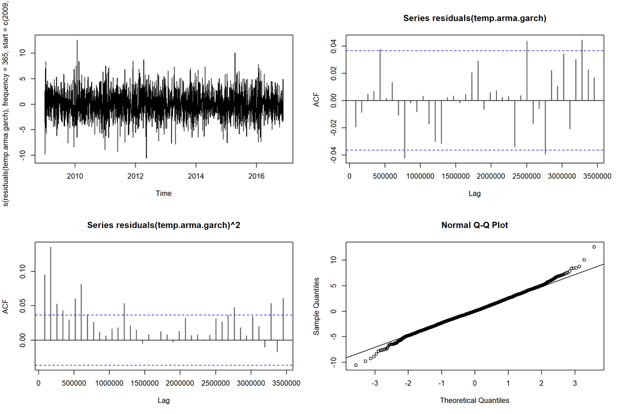

```r
par(mfrow=c(2,2))
ts.plot(ts(residuals(temp.arma.garch), frequency = 365, start = c(2009,1)))
acf(residuals(temp.arma.garch), lag.max = 40)
acf(residuals(temp.arma.garch)^2, lag.max = 40)
qqnorm(residuals(temp.arma.garch))
qqline(residuals(temp.arma.garch))
```

## ARMA-GARCH for modeling humidity

```r
# We take order of ARMA equal to (6,0,5)
# Find order for GARCH
test_modelAGG <- function(m,n){
    spec = ugarchspec(variance.model=list(garchOrder=c(m,n)),
                      mean.model=list(armaOrder=c(6,5),
                                      external.regressors = as.matrix(harmonic.train),
                                      include.mean=T), distribution.model="std")
    fit = ugarchfit(spec, daily.humidity.train.ts, solver = 'hybrid')
    current.aic = infocriteria(fit)[1]
    df = data.frame(m,n,current.aic)
    names(df) <- c("m","n","AIC")
    return(df)
}

ordersAGG = data.frame(Inf,Inf,Inf)
names(ordersAGG) <- c("m","n","AIC")

for (m in 0:2){
    for (n in 0:2){
        possibleError <- tryCatch(
            ordersAGG<-rbind(ordersAGG,test_modelAGG(m,n)),
            error=function(e) e
        )
        if(inherits(possibleError, "error")) next
    }
}
ordersAGG <- ordersAGG[order(-ordersAGG$AIC),]
tail(ordersAGG)
```

```r
# Update ARMA using GARCH = (2,2)
test_modelAGA <- function(p,q){
    spec = ugarchspec(variance.model=list(garchOrder=c(2,2)),
                      mean.model=list(armaOrder=c(p,q),
                                      external.regressors = as.matrix(harmonic.train),
                                      include.mean=T),
                      distribution.model="std")
    fit = ugarchfit(spec, daily.humidity.train.ts, solver = 'hybrid')
    current.aic = infocriteria(fit)[1]
    df = data.frame(p,q,current.aic)
    names(df) <- c("p","q","AIC")
    return(df)
}

ordersAGA = data.frame(Inf,Inf,Inf)
names(ordersAGA) <- c("p","q","AIC")
for (p in 0:7){
    for (q in 0:7){
        possibleError <- tryCatch(
            ordersAGA<-rbind(ordersAGA,test_modelAGA(p,q)),
            error=function(e) e
        )
        if(inherits(possibleError, "error")) next
    }
}
ordersAGA <- ordersAGA[order(-ordersAGA$AIC),]
tail(ordersAGA)
```

```r
# Update order for GARCH using ARMA (4,4)
test_modelAGG <- function(m,n){
    spec = ugarchspec(variance.model=list(garchOrder=c(m,n)),
                      mean.model=list(armaOrder=c(4,4),
                                      external.regressors = as.matrix(harmonic.train),
                                      include.mean=T), distribution.model="std")
    fit = ugarchfit(spec, daily.humidity.train.ts, solver = 'hybrid')
    current.aic = infocriteria(fit)[1]
    df = data.frame(m,n,current.aic)
    names(df) <- c("m","n","AIC")
    return(df)
}

ordersAGG = data.frame(Inf,Inf,Inf)
names(ordersAGG) <- c("m","n","AIC")

for (m in 0:2){
    for (n in 0:2){
        possibleError <- tryCatch(
            ordersAGG<-rbind(ordersAGG,test_modelAGG(m,n)),
            error=function(e) e
        )
        if(inherits(possibleError, "error")) next
    }
}
ordersAGG <- ordersAGG[order(-ordersAGG$AIC),]
tail(ordersAGG)
```

The final iteration shows that the optimal orders for modeling the Humidity are (4,4)x(2,2).

```r
spec.3 = ugarchspec(variance.model=list(garchOrder=c(2,2)),
                    mean.model=list(armaOrder=c(4,4),
                                    external.regressors = as.matrix(harmonic.train),
                                    include.mean=T),
                    distribution.model="std")
hum.arma.garch<-ugarchfit(spec.3,daily.humidity.train.ts,solver='hybrid')
hum.arma.garch
```

```
##
## *---------------------------------*
## *          GARCH Model Fit        *
## *---------------------------------*
##
## Conditional Variance Dynamics
## -----------------------------------
## GARCH Model  : sGARCH(2,2)
## Mean Model   : ARFIMA(4,0,4)
## Distribution : std
##
## Optimal Parameters
## ------------------------------------
##         Estimate  Std. Error     t value Pr(>|t|)
## mu      3.500768    0.330031    10.60739 0.000000
## ar1     0.308134    0.018165    16.96343 0.000000
## ar2     0.537172    0.013392    40.11069 0.000000
## ar3     0.747072    0.011637    64.19572 0.000000
## ar4    -0.598543    0.018237   -32.82062 0.000000
## ma1     0.661247    0.009524    69.42781 0.000000
## ma2    -0.130577    0.003380   -38.62876 0.000000
## ma3    -0.973964    0.000099 -9829.31373 0.000000
## ma4    -0.251986    0.010658   -23.64262 0.000000
## mxreg1 -0.742319    0.200173    -3.70839 0.000209
## mxreg2 -0.752974    0.187395    -4.01810 0.000059
## omega   0.020947    0.007802     2.68463 0.007261
## alpha1  0.092836    0.016579     5.59977 0.000000
## alpha2  0.026632    0.017222     1.54644 0.121998
## beta1   0.027797    0.051751     0.53713 0.591176
## beta2   0.832316    0.047088    17.67587 0.000000
## shape   8.804101    1.482161     5.94004 0.000000
##
## Robust Standard Errors:
##         Estimate  Std. Error     t value Pr(>|t|)
## mu      3.500768    0.355643  9.8435e+00 0.000000
## ar1     0.308134    0.018953  1.6258e+01 0.000000
## ar2     0.537172    0.012303  4.3662e+01 0.000000
## ar3     0.747072    0.010424  7.1671e+01 0.000000
## ar4    -0.598543    0.020016 -2.9903e+01 0.000000
## ma1     0.661247    0.009254  7.1456e+01 0.000000
```

[output cut: 76 more lines]

```
## Negative Sign Bias  0.9059 3.651e-01
## Positive Sign Bias  1.2215 2.220e-01
## Joint Effect       27.4704 4.691e-06 ***
##
##
## Adjusted Pearson Goodness-of-Fit Test:
## ------------------------------------
##   group statistic p-value(g-1)
## 1    20     37.84     0.006221
## 2    30     57.68     0.001191
## 3    40     63.45     0.007954
## 4    50     74.16     0.011659
##
##
## Elapsed time : 1.530923
```

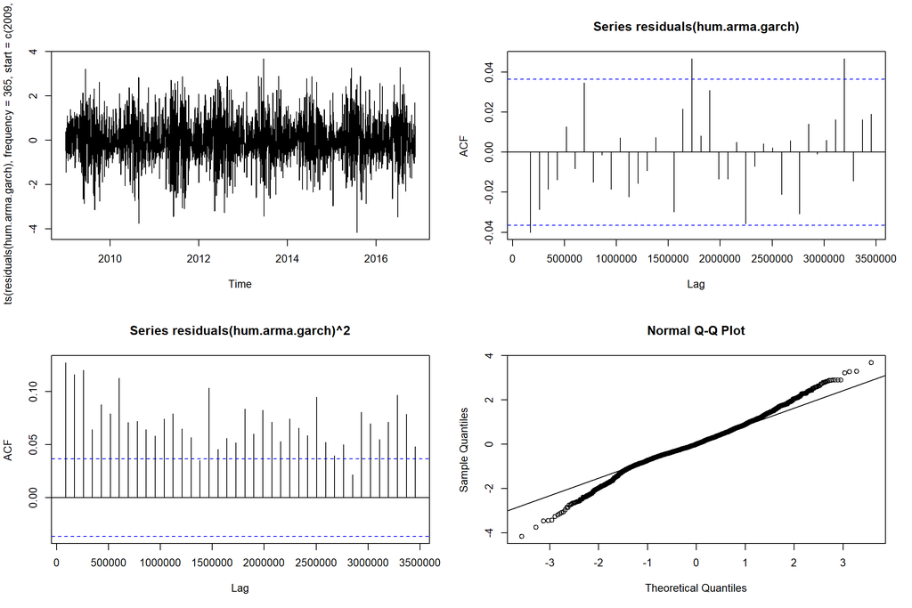

```r
par(mfrow=c(2,2))
ts.plot(ts(residuals(hum.arma.garch), frequency = 365, start = c(2009,1)))
acf(residuals(hum.arma.garch), lag.max = 40)
acf(residuals(hum.arma.garch)^2, lag.max = 40)
qqnorm(residuals(hum.arma.garch))
qqline(residuals(hum.arma.garch))
```

## Arma-Garch Prediction

```r
prediction.p.arma.garch <- data.frame(Inf, Inf, Inf)
names(prediction.p.arma.garch) <- c('prediction', 'lower', 'upper')
prediction.t.arma.garch <- data.frame(Inf, Inf, Inf)
names(prediction.t.arma.garch) <- c('prediction', 'lower', 'upper')
prediction.h.arma.garch <- data.frame(Inf, Inf, Inf)
names(prediction.h.arma.garch) <- c('prediction', 'lower', 'upper')

for (i in 1:6) {
  data <- daily.training.data
  if (i >= 2) {
    data <- rbind(data, daily.testing.data[c(1:((i - 1)*7)),])
  }

  spec.p = ugarchspec(variance.model=list(garchOrder=c(1,1)),
                      mean.model=list(armaOrder=c(6,5),
                                      external.regressors = as.matrix(harmonic.all[c(1:nrow(data)),]),
                                      include.mean=T),
                      distribution.model="std")
  arma.garch.p <-ugarchfit(spec.p, data$pressure,solver='hybrid')
  fore <- ugarchforecast(arma.garch.p, n.ahead = 7)
  fore <- fore@forecast
  temp <- data.frame(fore$seriesFor,
                     fore$seriesFor - 1.96 * fore$sigmaFor,
                     fore$seriesFor + 1.96 * fore$sigmaFor)
  names(temp) <- c('prediction', 'lower', 'upper')
  prediction.p.arma.garch <- rbind(prediction.p.arma.garch, temp)


  spec.t = ugarchspec(variance.model=list(garchOrder=c(1,1)),
                      mean.model=list(armaOrder=c(6,5),
                                      external.regressors = as.matrix(harmonic.all[c(1:nrow(data)),]),
                                      include.mean=T),
                      distribution.model="std")
  arma.garch.t <-ugarchfit(spec.t, data$temperature,solver='hybrid')
  fore <- ugarchforecast(arma.garch.t, n.ahead = 7)
  fore <- fore@forecast
  temp <- data.frame('prediction' = fore$seriesFor,
                     'lower' = fore$seriesFor - 1.96 * fore$sigmaFor,
                     'upper' = fore$seriesFor + 1.96 * fore$sigmaFor)
  names(temp) <- c('prediction', 'lower', 'upper')
  prediction.t.arma.garch <- rbind(prediction.t.arma.garch, temp)

  spec.h = ugarchspec(variance.model=list(garchOrder=c(2,2)),
                      mean.model=list(armaOrder=c(4,4),
                                      external.regressors = as.matrix(harmonic.all[c(1:nrow(data)),]),
                                      include.mean=T),
                      distribution.model="std")
  arma.garch.h <-ugarchfit(spec.h, data$humidity,solver='hybrid')
  fore <- ugarchforecast(arma.garch.h, n.ahead = 7)
  fore <- fore@forecast
  temp <- data.frame('prediction' = fore$seriesFor,
                     'lower' = fore$seriesFor - 1.96 * fore$sigmaFor,
                     'upper' = fore$seriesFor + 1.96 * fore$sigmaFor)
  names(temp) <- c('prediction', 'lower', 'upper')
  prediction.h.arma.garch <- rbind(prediction.h.arma.garch, temp)

}
prediction.p.arma.garch <- prediction.p.arma.garch[-1,]
prediction.p.arma.garch$date <- daily.testing.data$date

prediction.t.arma.garch <- prediction.t.arma.garch[-1,]
prediction.t.arma.garch$date <- daily.testing.data$date

prediction.h.arma.garch <- prediction.h.arma.garch[-1,]
prediction.h.arma.garch$date <- daily.testing.data$date

arma.garch.prediction <- list(prediction.p.arma.garch, prediction.t.arma.garch, prediction.h.arma.garch)
# save(arma.garch.prediction, file = 'arma-garch-prediction.RData')
```

### Prediction Plots

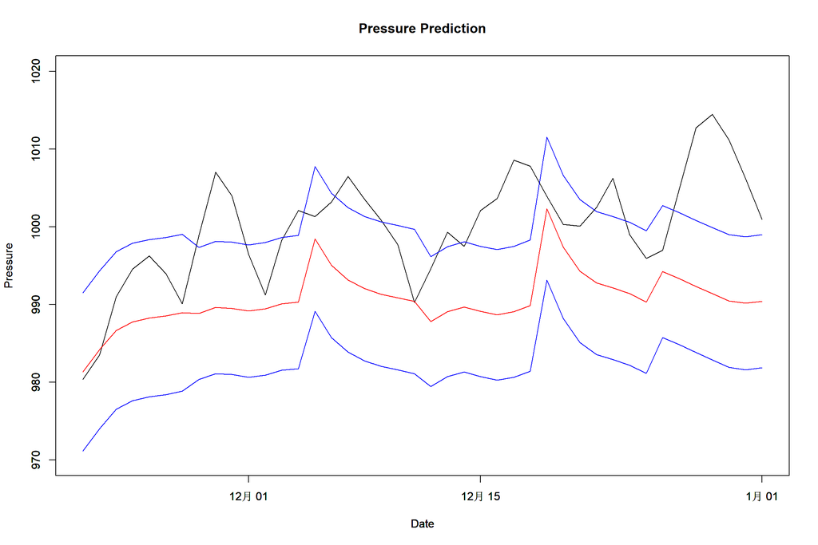

```r
load('arma-garch-prediction.RData')
prediction.p.arma.garch <- arma.garch.prediction[[1]]
prediction.t.arma.garch <- arma.garch.prediction[[2]]
prediction.h.arma.garch <- arma.garch.prediction[[3]]

plot(daily.testing.data$date, daily.testing.data$pressure, type = 'l', ylim = c(970,1020), main = 'Pressure Prediction', ylab = 'Pressure', xlab = 'Date')
par(new = T)
plot(daily.testing.data$date, prediction.p.arma.garch$prediction, type = 'l', col = 'red', ylim = c(970,1020), ylab = '', cex = 0.6, xlab = 'Date')
par(new = T)
plot(daily.testing.data$date, prediction.p.arma.garch$lower, type = 'l', col = 'blue', ylim = c(970,1020), ylab = '', cex = 0.6, xlab = 'Date')
par(new = T)
plot(daily.testing.data$date, prediction.p.arma.garch$upper, type = 'l', col = 'blue', ylim = c(970,1020), ylab = '', cex = 0.6, xlab = 'Date')
```

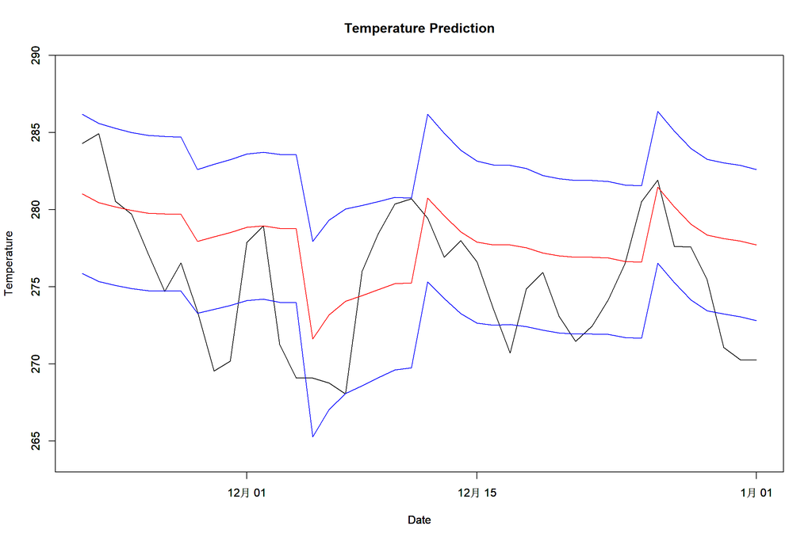

```r
plot(daily.testing.data$date, daily.testing.data$temperature, type = 'l', ylim = c(264,289), main = 'Temperature Prediction', ylab = 'Temperature', xlab = 'Date')
par(new = T)
plot(daily.testing.data$date, prediction.t.arma.garch$prediction, type = 'l', col = 'red', ylim = c(264,289), ylab = '', cex = 0.6, xlab = 'Date')
par(new = T)
plot(daily.testing.data$date, prediction.t.arma.garch$lower, type = 'l', col = 'blue', ylim = c(264,289), ylab = '', cex = 0.6, xlab = 'Date')
par(new = T)
plot(daily.testing.data$date, prediction.t.arma.garch$upper, type = 'l', col = 'blue', ylim = c(264,289), ylab = '', cex = 0.6, xlab = 'Date')
```

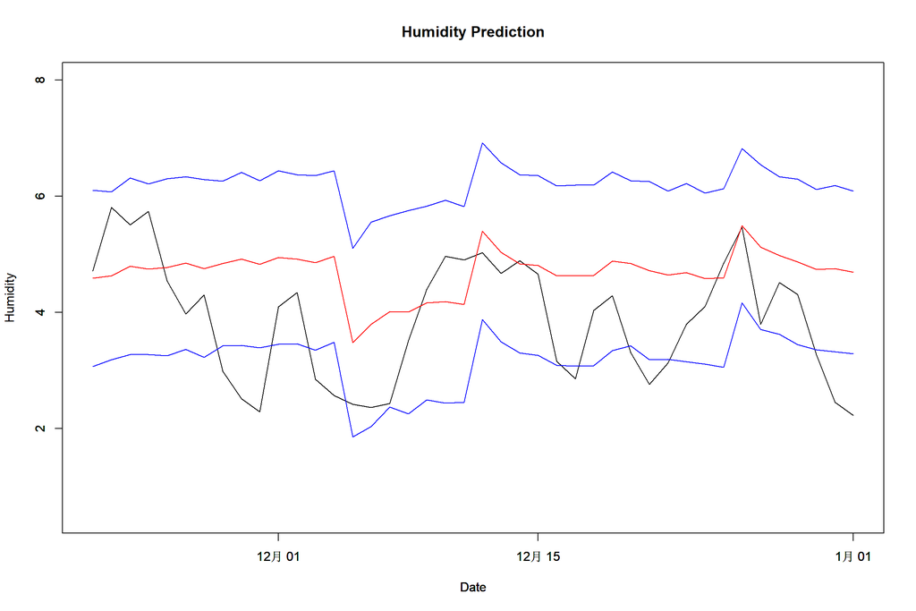

```r
plot(daily.testing.data$date, daily.testing.data$humidity, type = 'l', ylim = c(0.5,8), main = 'Humidity Prediction', ylab = 'Humidity', xlab = 'Date')
par(new = T)
plot(daily.testing.data$date, prediction.h.arma.garch$prediction, type = 'l', col = 'red', ylim = c(0.5,8), ylab = '', cex = 0.6, xlab = 'Date')
par(new = T)
plot(daily.testing.data$date, prediction.h.arma.garch$lower, type = 'l', col = 'blue', ylim = c(0.5,8), ylab = '', cex = 0.6, xlab = 'Date')
par(new = T)
plot(daily.testing.data$date, prediction.h.arma.garch$upper, type = 'l', col = 'blue', ylim = c(0.5,8), ylab = '', cex = 0.6, xlab = 'Date')
```

# VAR modeling

```r
train.data <- cbind(daily.pressure.train.ts, daily.temp.train.ts, daily.humidity.train.ts)
test.data <- cbind(daily.pressure.test.ts, daily.temp.test.ts, daily.humidity.test.ts)
colnames(train.data) <- c("pressure", "temperature", "humidity")
var.select<-VARselect(train.data, exogen=harmonic.train, type="both")
var.select$selection
```

```
## AIC(n)  HQ(n)  SC(n) FPE(n)
##      4      3      3      4
```

```r
var1<-VAR(train.data,p=3, exogen=harmonic.train, type="both")
summary(var1)
```

```
##
## VAR Estimation Results:
## =========================
## Endogenous variables: pressure, temperature, humidity
## Deterministic variables: both
## Sample size: 2876
## Log Likelihood: -17670.276
## Roots of the characteristic polynomial:
## 0.8093 0.7514 0.667 0.4092 0.4092 0.3992 0.3992 0.2819 0.2819
## Call:
## VAR(y = train.data, p = 3, type = "both", exogen = harmonic.train)
##
##
## Estimation results for equation pressure:
## =========================================
## pressure = pressure.l1 + temperature.l1 + humidity.l1 + pressure.l2 + temperature.l2 + humidity.l2 + pressure.l3 + temperature.l3 + humidity.l3 + const + trend + exo1 + exo2
##
##                  Estimate Std. Error t value Pr(>|t|)
## pressure.l1     1.054e+00  2.058e-02  51.218  < 2e-16 ***
## temperature.l1 -1.804e-01  4.883e-02  -3.694 0.000225 ***
## humidity.l1     8.324e-01  1.272e-01   6.542 7.16e-11 ***
## pressure.l2    -4.156e-01  2.948e-02 -14.097  < 2e-16 ***
## temperature.l2  5.542e-02  6.278e-02   0.883 0.377425
## humidity.l2    -5.627e-01  1.599e-01  -3.518 0.000441 ***
## pressure.l3     1.391e-01  2.059e-02   6.755 1.72e-11 ***
## temperature.l3  5.033e-02  4.924e-02   1.022 0.306826
## humidity.l3     5.591e-02  1.272e-01   0.439 0.660402
## const           2.391e+02  1.746e+01  13.692  < 2e-16 ***
## trend           1.409e-04  1.058e-04   1.331 0.183196
## exo1            1.458e-01  1.879e-01   0.776 0.437845
## exo2            1.302e-02  2.184e-01   0.060 0.952466
## ---
## Signif. codes:  0 '***' 0.001 '**' 0.01 '*' 0.05 '.' 0.1 ' ' 1
##
##
## Residual standard error: 4.574 on 2863 degrees of freedom
## Multiple R-Squared: 0.6748,  Adjusted R-squared: 0.6734
## F-statistic: 495.1 on 12 and 2863 DF,  p-value: < 2.2e-16
##
##
```

[output cut: 51 more lines]

```
## F-statistic:  1794 on 12 and 2863 DF,  p-value: < 2.2e-16
##
##
##
## Covariance matrix of residuals:
##             pressure temperature humidity
## pressure      20.923      -4.692  -1.3364
## temperature   -4.692       5.835   1.4163
## humidity      -1.336       1.416   0.7874
##
## Correlation matrix of residuals:
##             pressure temperature humidity
## pressure      1.0000     -0.4246  -0.3293
## temperature  -0.4246      1.0000   0.6607
## humidity     -0.3293      0.6607   1.0000
```

```r
prediction.p.var <- data.frame(Inf, Inf, Inf)
names(prediction.p.var) <- c('fcst', 'lower', 'upper')
prediction.t.var <- data.frame(Inf, Inf, Inf)
names(prediction.t.var) <- c('fcst', 'lower', 'upper')
prediction.h.var <- data.frame(Inf, Inf, Inf)
names(prediction.h.var) <- c('fcst', 'lower', 'upper')

for (i in 1:6) {
  data <- train.data
  if (i >= 2) {
    data <- rbind(data, test.data[c(1:((i - 1)*7)),])
  }
  exo <- harmonic.all[1:nrow(data),]
  new.exo <- harmonic.test[(1 + (i - 1) * 7):(i * 7),]

  varx<-VAR(data,p=3, exogen=exo, type="both")
  pred <- predict(varx, n.ahead = 7, ci = 0.95, dumvar = new.exo)
  pred <- pred$fcst
  prediction.p.var <- rbind(prediction.p.var, pred$pressure[,1:3])
  prediction.t.var <- rbind(prediction.t.var, pred$temperature[,1:3])
  prediction.h.var <- rbind(prediction.h.var, pred$humidity[,1:3])
}

prediction.p.var <- prediction.p.var[-1,]
prediction.p.var$date <- daily.testing.data$date

prediction.t.var <- prediction.t.var[-1,]
prediction.t.var$date <- daily.testing.data$date

prediction.h.var <- prediction.h.var[-1,]
prediction.h.var$date <- daily.testing.data$date

varx.prediction <- list(prediction.p.var, prediction.t.var, prediction.h.var)
# save(varx.prediction, file = 'varx-prediction.RData')
```